# OncoMix Vignette

Daniel G. Piqué

2017-09-13

## 1. Introduction

### 1.1 Motivation for developing OncoMix

The advent of large, well-curated databases, such as the [genomic data commons](https://gdc.cancer.gov/), that contain RNA sequencing data from hundreds of patient tumors has made it possible to identify oncogene candidates solely based off of patterns present in mRNA expression data. OncoMix is the first method developed to identify oncogenes in a visually-interpretable manner from RNA-sequencing data in large cohorts of patients.

OncoMix is an R package for identifying oncogene candidates based off of 2-component Gaussian mixture models. It estimates parameters using the expectation maximization procedure as implemented in the R package mclust. This tutorial will demonstrate how to identify oncogene candidates from a set of mRNA sequencing data. We start by loading the package:

```r
#devtools::install_github("dpique/oncomix")
library(oncomix)
```

We then pose the following question, the answer to which forms the basis for this method:

### 1.2 What should the distribution of oncogene mRNA expression in a population of tumors and adjacent normal tissue ideally look like?

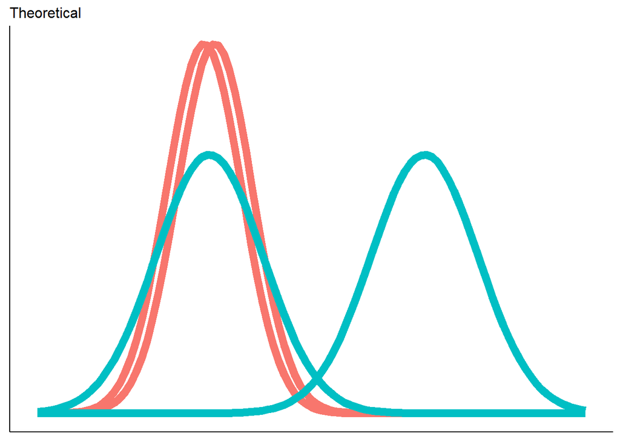

```r
library(ggplot2)
oncomix::oncoMixIdeal()
```

The x-axis represents mRNA expression values, with lower values toward the left and larger values (i.e. higher expression) toward the right. The y axis represents density. The teal curves represent the best-fitting Gaussian probability distribution (PD) over expression values from a single gene obtained from multiple tumor samples. The red-orange curves represent the PD over expression values from the same gene obtained from multiple adjacent normal tissue samples. This mixture model is applied once to the tumor data and again (separately) to the adjacent normal data, hence the 4 curves.

The advantage of applying a 2-component mixture model is that we are able to capture biologically-relevant clusters of gene expression that may naturally exist in the data. Otherwise, we might represent our data with just a single curve sitting in the middle of what really are 2 distinct clusters. Visually, we see that for a theoretical oncogene, there is a *subgroup* of tumors that overexpresses this gene relative to normal tissue.

### 1.3 Conceptual comparison of oncomix to classical differential expression methods

We now conceptually compare oncomix to the techniques employed by traditional differential expression analysis (e.g. Student’s t-test, as employed by [limma](https://www.ncbi.nlm.nih.gov/pubmed/25605792), or [DESeq2](https://www.ncbi.nlm.nih.gov/pubmed/25516281)). These approaches make strong assumptions – namely, that the data from a particular group are well-described by distributions with mass concentrated around a central value (such as a ‘mean’). If we were to use one of these approaches on a large dataset, our assumption would be that oncogenes are overexpressed in *every* tumor sample compared to normal tissue. This assumption can be visualized below:

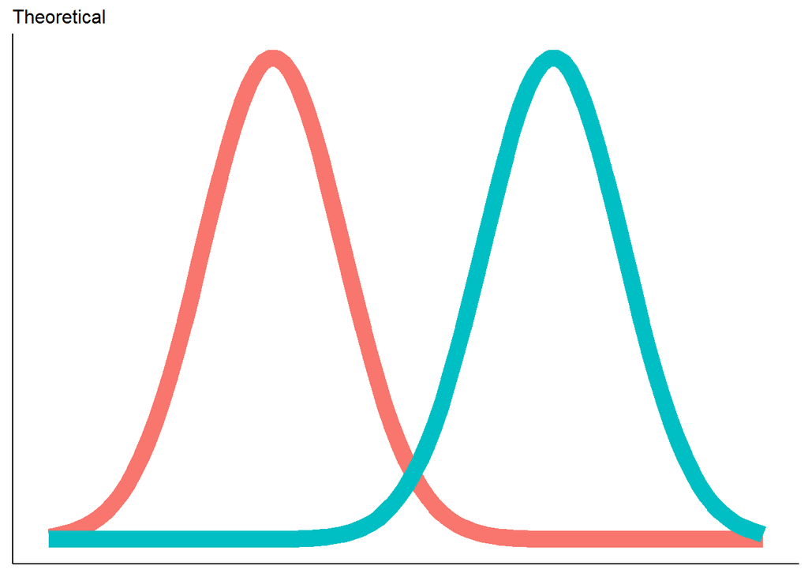

```r
oncoMixTraditionalDE()
```

The red-orange curve represents the gene expression values from the adjacent normal data, and the teal curve represents the gene expression values from the tumor data. Note, however, that the goal for a classical DE analysis, such as that employed by limma, would be to find genes that maximize the difference between these two curves. This approach does not represent our knowledge of how oncogenes are expressed in a population of individuals – that is, highly expressed in a subset of patient tumors, and lowly expressed in adjacent normal tissue.

## 2. Identifying Oncogene Candidates

### 2.1 Loading example data and exploring the `mixModelParams` object

```r
data(dfNmlIsof, dfTumorIsof, package="oncomix")

dim(dfNmlIsof)
```

```
## [1] 113 700
```

```r
dfNmlIsof[1:5, 1:5] #take a look at the matrix of mRNA expression data from adjacent normal samples
```

```
##                  uc001qoa.2 uc002jyg.1 uc011lsc.1 uc004cpd.1 uc011mgy.1
## TCGA-A7-A0CE-11A   1.972887  1.4882363   5.939032   1.816706   1.573477
## TCGA-A7-A0CH-11A   2.487751  0.9886728   6.711764   1.647932   1.337137
## TCGA-A7-A0D9-11A   1.534429  3.3637116   5.210523   1.295284   2.027953
## TCGA-A7-A0DB-11A   2.787777  3.3010141   5.664385   1.537309   2.070035
## TCGA-A7-A0DC-11A   1.821897  3.1279237   5.433401   1.533831   2.431077
```

```r
dim(dfTumorIsof)
```

```
## [1] 113 700
```

```r
dfTumorIsof[1:5, 1:5] #take a look at the matrix of mRNA expression data from tumors
```

```
##                  uc001qoa.2 uc002jyg.1 uc011lsc.1 uc004cpd.1 uc011mgy.1
## TCGA-A7-A0CE-01A   1.239980   3.154708   5.293854  0.8499161   0.684948
## TCGA-A7-A0CH-01A   1.780444   3.503748   5.622610  1.8031689   2.081580
## TCGA-A7-A0D9-01A   1.704665   2.432818   9.029952  2.5185153   3.343087
## TCGA-A7-A0DB-01A   2.390934   2.638793   6.077302  1.7353236   1.546985
## TCGA-A7-A0DC-01A   2.310899   1.893164   7.636221  1.8828744   2.415372
```

```r
mmParams = oncomix::mixModelParams(dfNmlIsof, dfTumorIsof) #fits the mixture models, will take a few minutes
head(mmParams)
```

```
##                 n.mu.1     n.mu.2       n.var    n.pi.1    t.mu.1   t.mu.2
## uc002jxc.2 1.250068025 1.83147135 0.116400229 0.7967701 1.7371897 4.285259
## uc001jrg.2 0.006952803 0.01324544 0.005531848 0.5003037 0.1113493 1.625321
## uc003aab.2 0.985454390 1.59242262 0.087878646 0.4896663 2.0035574 4.522943
## uc004cmb.2 0.385483412 0.87309050 0.046609881 0.6731112 1.1691973 3.389940
## uc002jfu.2 0.382007855 0.45789679 0.558312339 0.5189438 0.5591093 2.645615
## uc001lcs.1 0.600357282 1.45153880 0.178300764 0.6373414 0.3463322 2.934114
##                t.var    t.pi.1 deltaMu2   deltaMu1        SI     score
## uc002jxc.2 0.4368186 0.5943046 2.453788  0.4871217 1.0000000 1.4134475
## uc001jrg.2 0.1074420 0.7913964 1.612076  0.1043965 1.0000000 1.3947057
## uc003aab.2 0.6200912 0.7359520 2.930521  1.0181030 1.0000000 1.2044477
## uc004cmb.2 0.5000264 0.7992164 2.516849  0.7837139 1.0000000 1.1864992
## uc002jfu.2 0.3309116 0.6385413 2.187718  0.1771014 0.9911504 1.1114688
## uc001lcs.1 0.5330532 0.5976110 1.482575 -0.2540251 0.8849558 0.9072978
```

The object returned by `mixModelParams` is a dataframe with rows corresponding to genes and 12 columns containing mixture model parameters. The rows are sorted according to the `score` column, with the first row containing the highest oncomix score (defined below). The meaning of the dataframe columns are described below:

$$SI_i = \frac{1}{N}\sum_{j=1}^N \Bigg\{ \begin{array}{ll} 1,~ if~x_{ij} < \frac{\mu_{iLT}+\mu_{iHT}}{2} \\
0, ~ otherwise
\end{array},$$

### 2.3 Selecting genes that appear most like idealized oncogene candidate

We can now use the `mmParams` dataframe to figure out which of our isoforms in our gene set are most similar in terms of their distribution to our ideal oncogene candidate.

For example, lets say that we wanted to select a subset of gene isoforms that most resembled the theoretically ideal oncogene. We can capture all of the genes meeting or exceeding specified thresholds using the `topGeneQuant` function. Here, we want to maximize `deltMu2`, minimize `deltMu1`, and maximize the `SI`.

```r
topGeneQuant = oncomix::topGeneQuants(mmParams, deltMu2Thresh = 99, deltMu1Thresh = 10, siThresh = .99)
print(topGeneQuant)
```

```
##               n.mu.1    n.mu.2      n.var    n.pi.1   t.mu.1   t.mu.2
## uc002jxc.2 1.2500680 1.8314714 0.11640023 0.7967701 1.737190 4.285259
## uc004cmb.2 0.3854834 0.8730905 0.04660988 0.6731112 1.169197 3.389940
##                t.var    t.pi.1 deltaMu2  deltaMu1 SI    score
## uc002jxc.2 0.4368186 0.5943046 2.453788 0.4871217  1 1.413447
## uc004cmb.2 0.5000264 0.7992164 2.516849 0.7837139  1 1.186499
```

The results of the `topGeneQuants` function is to return a subsetted dataframe containing only those isoforms that met or exceeded the specified threshold. Here, there were 2 isoforms.

We can also select the top $N$ genes that most closely resemble the oncogene candidate by simply selecting the first $N$ rows from the `mmParams` object (e.g. `mmParams[1:N,]`). This is because the `mixModelParams` function returns a dataframe sorted by the score, with the 1st row containing the isoform with the highest score. There is an explanation of how the score is calculated above.

```r
mmParams.top10 = mmParams[1:10,]
print(mmParams.top10)
```

```
##                 n.mu.1     n.mu.2       n.var    n.pi.1     t.mu.1
## uc002jxc.2 1.250068025 1.83147135 0.116400229 0.7967701  1.7371897
## uc001jrg.2 0.006952803 0.01324544 0.005531848 0.5003037  0.1113493
## uc003aab.2 0.985454390 1.59242262 0.087878646 0.4896663  2.0035574
## uc004cmb.2 0.385483412 0.87309050 0.046609881 0.6731112  1.1691973
## uc002jfu.2 0.382007855 0.45789679 0.558312339 0.5189438  0.5591093
## uc001lcs.1 0.600357282 1.45153880 0.178300764 0.6373414  0.3463322
## uc010tgs.1 0.893283005 1.05416810 0.179040709 0.5385148  1.3478455
## uc003yqc.1 4.208205968 4.27383134 0.051540764 0.5289734  4.7150533
## uc002dwc.2 9.293023652 9.41161776 0.183687289 0.4974137 10.1034656
## uc001guh.2 1.430670482 1.92416525 0.110274426 0.4216897  1.9201509
##               t.mu.2     t.var    t.pi.1 deltaMu2   deltaMu1        SI
## uc002jxc.2  4.285259 0.4368186 0.5943046 2.453788  0.4871217 1.0000000
## uc001jrg.2  1.625321 0.1074420 0.7913964 1.612076  0.1043965 1.0000000
## uc003aab.2  4.522943 0.6200912 0.7359520 2.930521  1.0181030 1.0000000
## uc004cmb.2  3.389940 0.5000264 0.7992164 2.516849  0.7837139 1.0000000
## uc002jfu.2  2.645615 0.3309116 0.6385413 2.187718  0.1771014 0.9911504
## uc001lcs.1  2.934114 0.5330532 0.5976110 1.482575 -0.2540251 0.8849558
## uc010tgs.1  2.959714 0.4029768 0.7233166 1.905546  0.4545625 0.9911504
## uc003yqc.1  5.678098 0.1911460 0.6652337 1.404266  0.5068473 1.0000000
## uc002dwc.2 11.302811 0.3124464 0.7678767 1.891193  0.8104420 0.9911504
## uc001guh.2  3.423634 0.3555573 0.7444933 1.499468  0.4894804 0.9911504
##                score
## uc002jxc.2 1.4134475
## uc001jrg.2 1.3947057
## uc003aab.2 1.2044477
## uc004cmb.2 1.1864992
## uc002jfu.2 1.1114688
## uc001lcs.1 0.9072978
## uc010tgs.1 0.8612763
## uc003yqc.1 0.6547324
## uc002dwc.2 0.5794439
## uc001guh.2 0.5393407
```

## 3. Visualize the output

### 3.1 Visualize isoforms with a high SI & oncomix score

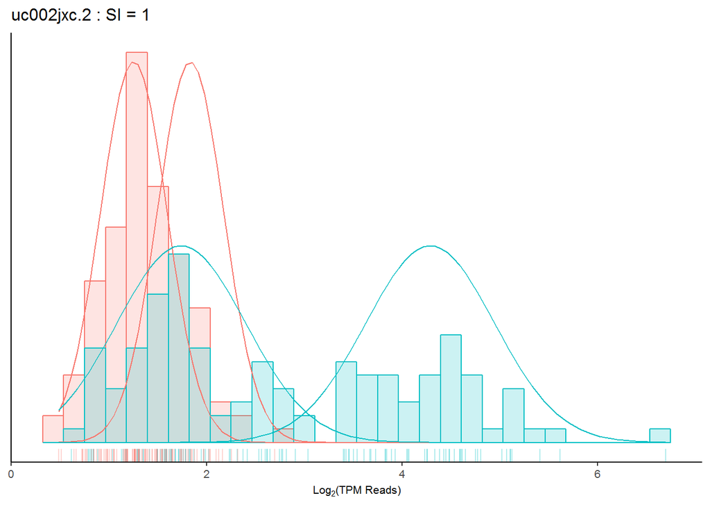

```r
isof = "uc002jxc.2"
plotGeneHist(mmParams, dfNmlIsof, dfTumorIsof, isof)
```

Next, we will create a scatterplot with the axes corresponding to the differences between component means. Our oncogene candidates will be those genes that appear in the upper right quadrant of this scatterplot. The x axis corresponds to the difference between the means of the curves with the larger Gaussians (`deltaMu2`), and the y axis corresponds to the difference between the means of the curves with the smaller Gaussians (`deltaMu1`) between the two treatments.

Here, $\alpha$ (in the title) is a term that is present in the denominator of the value of the y-axis and functions as an automatic scaling parameter to set the range of the y-axis to be approximately equal to the range of the x-axis.

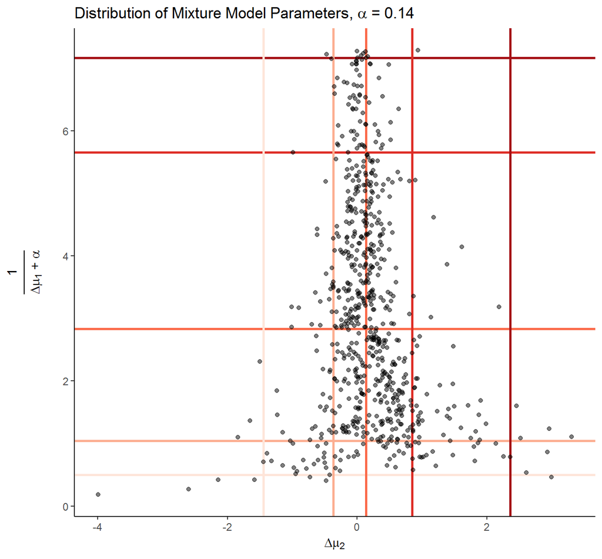

```r
scatterMixPlot(mmParams)
```

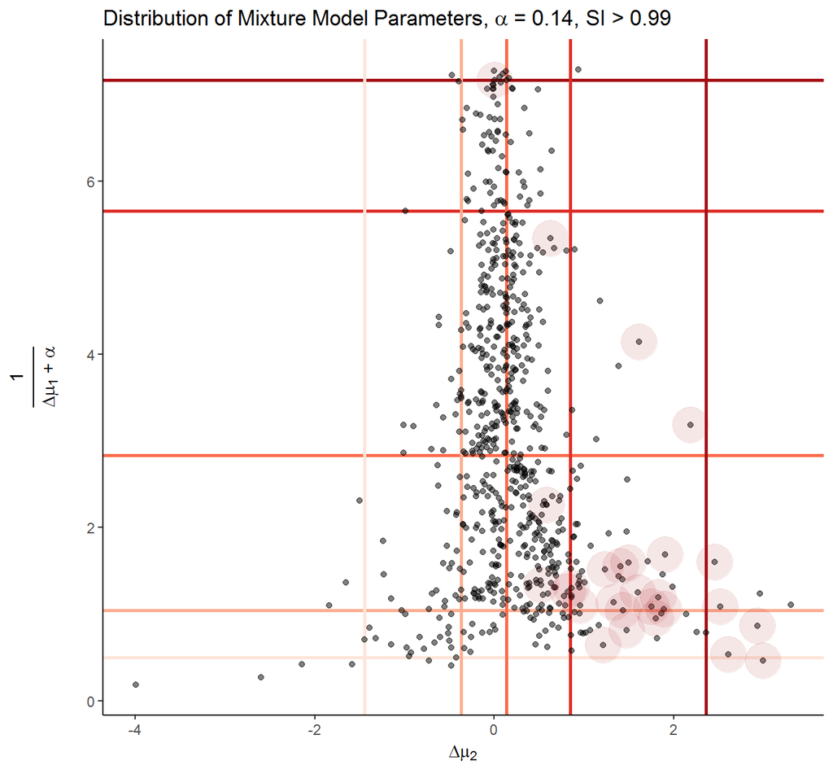

```r
scatterMixPlot(mmParams, selIndThresh = .99)
```

We can also highlight where the top 10 isoforms with the highest score fall in the scatterplot.

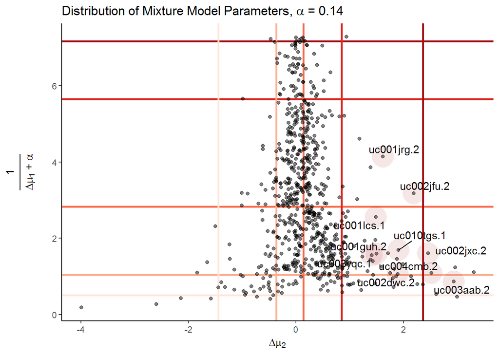

```r
scatterMixPlot(mmParams = mmParams, gene_labels = rownames(mmParams.top10))
```

### 3.2 Visualize the distribution of isoforms that map to oncogenes in an online database

We can check the distribution of the isoforms that map to known human oncogenes. To do this, we will use genes classified as oncogenes from the [ONGene database](http://ongene.bioinfo-minzhao.org/), which is first literature-curated database of oncogenes. This paper was published in 2017.

We will then map the oncogenes in the database (which are in gene symbols) to ucsc isoforms, which is the gene format that we have in our original datasets, using an R interface to the public UCSC MySQL database. We’ll show where the top 5 isoforms mapping to oncogenes in the ONGene database land on this scatterplot.

```r
#install.packages("RMySQL")
library(RMySQL)

#read in a table of known human oncogenes from the ONGene database
ongene = read.table("http://ongene.bioinfo-minzhao.org/ongene_human.txt", header = T, sep = "\t", quote = "", stringsAsFactors = FALSE, row.names = NULL)

#send a sql query to UCSC to map the human oncogenes to ucsc isoform ids
ucsc_genome <- dbConnect(MySQL(), user="genome",
                         host="genome-mysql.cse.ucsc.edu", db = 'hg19')
createGeneQuery = function(name){ #name is a character vector
  p1 = paste(name, collapse = '\',\'')
  p2 = paste('(\'',p1, '\')',sep ="")
  return(p2)
}
gene_q = createGeneQuery(ongene$OncogeneName)
query_res = dbGetQuery(ucsc_genome, paste0("SELECT kgID, geneSymbol FROM kgXref WHERE geneSymbol IN ", gene_q, " ;"))
dbDisconnect(ucsc_genome)
```

```
## [1] TRUE
```

```r
#Merge the query_res & mmParams dataframes
query_res$kgID.s = substr(query_res$kgID, 1,8)
mmParams$kgID.s = substr(rownames(mmParams), 1,8)
mmParams$kgID = rownames(mmParams)
mmParams.m = merge(mmParams, query_res, by = "kgID.s", all.x = T)
rownames(mmParams.m) = mmParams.m$kgID.x

# Show the top 5 isoforms with the highest score
#in our dataset that map to known oncogenes
mmParams.m = mmParams.m[with(mmParams.m, order(-score)), ]
mmParams.m.s = subset(mmParams.m, !is.na(geneSymbol))[1:5,]
print(mmParams.m.s)
```

```
##              kgID.s    n.mu.1    n.mu.2      n.var    n.pi.1    t.mu.1
## uc003oup.2 uc003oup 1.7562421 2.3786388 0.12487674 0.7730556 1.9883747
## uc002xxh.1 uc002xxh 0.4560398 1.4892669 0.24518796 0.4194020 0.9404896
## uc002bls.2 uc002bls 0.2984879 0.6211827 0.01947533 0.7187925 0.3545541
## uc001gmi.3 uc001gmi 0.1444637 1.4093875 0.09445765 0.6551238 0.1805888
## uc001fmq.2 uc001fmq 4.1282249 4.2659677 0.22455842 0.4735916 3.9730294
##               t.mu.2      t.var    t.pi.1  deltaMu2    deltaMu1        SI
## uc003oup.2 3.3428559 0.28818297 0.7293117 0.9642171  0.23213265 0.9380531
## uc002xxh.1 3.1973170 0.79205319 0.2116396 1.7080501  0.48444982 0.9115044
## uc002bls.2 0.8321796 0.02351133 0.7950209 0.2109969  0.05606616 0.8318584
## uc001gmi.3 1.8023104 0.13572157 0.7174308 0.3929229  0.03612517 0.7079646
## uc001fmq.2 4.7407613 0.31292535 0.5434014 0.4747936 -0.15519546 0.6371681
##                 score     kgID.x     kgID.y geneSymbol
## uc003oup.2 0.29926211 uc003oup.2 uc003oup.3      DNPH1
## uc002xxh.1 0.16986716 uc002xxh.1 uc002xxh.1      AURKA
## uc002bls.2 0.09312160 uc002bls.2 uc002bls.4     AKAP13
## uc001gmi.3 0.08964142 uc001gmi.3 uc001gmi.4       ABL2
## uc001fmq.2 0.05894143 uc001fmq.2 uc001fmq.2    ARHGEF2
```

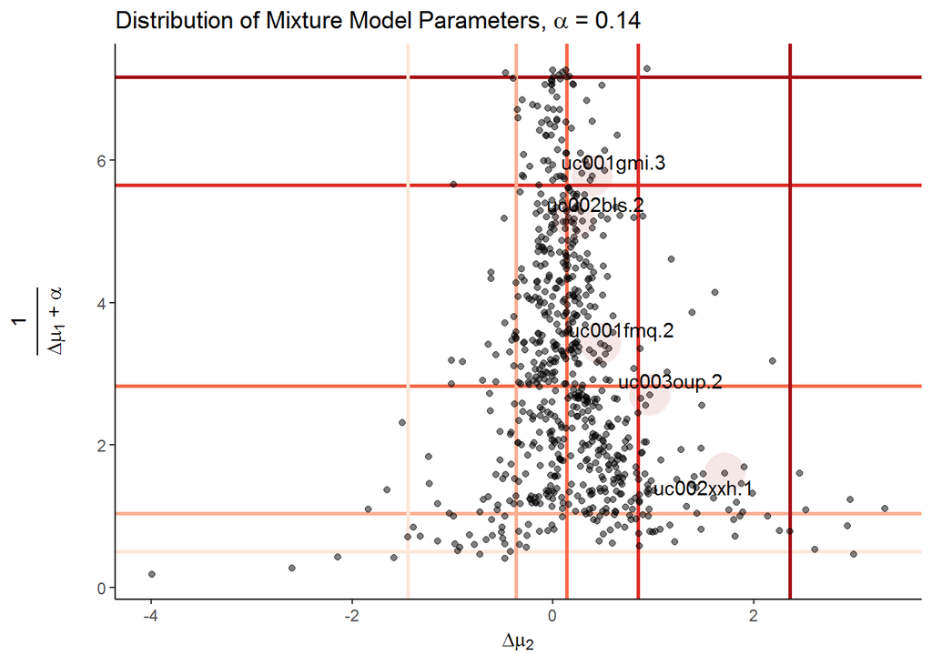

```r
scatterMixPlot(mmParams = mmParams, gene_labels = rownames(mmParams.m.s))
```

If you are interested in a particular oncogene, then you can plug the name of that gene (as long as it is in your original dataset) into the `gene_labels` argument of the `scatterMixPlot` function, which will highlight those genes entered into the `gene_labels` argument on the scatterplot.

Note: Not all well-characterized oncogenes fall into or near the upper right quadrant of this scatterplot (explored more in the analysis below). This is expected because oncogenes can arise via a variety of mechanisms, such as via mutational activation (eg BRAF V600E), which may not be associated with increased expression of the gene. mRNA overexpresion is one of several ways that an oncogene can drive tumor behavior, and it is this class of oncogenes that our method seeks to detect.

### 3c. Visualize the distribution of the OncoMix score

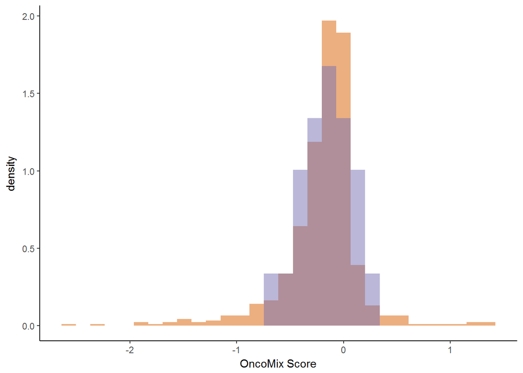

```r
library(RColorBrewer)
col = brewer.pal(3, "Dark2")
ggplot(mmParams.m, aes(x = score, y = ..density.., fill=is.na(geneSymbol))) +
  geom_histogram(data=subset(mmParams.m, is.na(geneSymbol)), fill = col[2], alpha = 0.5)+
  geom_histogram(data=subset(mmParams.m, !is.na(geneSymbol)), fill = col[3], alpha = 0.5)+ theme_classic() + xlab("OncoMix Score")+ theme_classic()
```

Please email me at daniel.pique@med.einstein.yu.edu with any suggestions, questions, or comments. Thank you!